# Stat 226 - Lecture 2

01/16/14

### Announcements

- “Quiz” 1 is available on Blackboard and is due Sunday (it's just a survey).
- Homework 1 is now available on Blackboard and is due next week Thursday.
- My office hours will be on Mondays at 12:00-1:50pm in Snedecor 1205.
  - Except for this upcoming Monday (MLK Day).
  - The full office hours schedule is up on Blackboard.
- Any questions about the syllabus, Chapter 1 or Chapter 2?
- **Question**: How much should KPacks charge for their backpack? More specifically, what is the average amount potential customers are willing to spend?
- **Population**:
  - Potential customers.
- **Sample**:
  - Fall 2013 STAT 226 section D students (in your case…your neighbors).
- **Parameter**:
  - The **average (or mean)** amount potential customers are willing to pay.
- **Statistic**:
  - The **average (or mean)** amount fall 2013 STAT 226 section D students (in your case…your neighbors) are willing to pay.

### Digging Deeper

- A population and sample *could* be any size that you wish…it really all depends on your question of interest.
  - However, your sample *must* be a subset of your population. That is, your sample should **never** contain something outside of your population.
  - Is this the case for the KPacks example???
  - Well, that probably depends on your definition of potential customer…
  - Even if everyone here is a potential customer, would this class be a *good* representation of all potential customers?
  - No, this is a case of **convenience** sampling. The **statistic** is probably not a good estimate of the **parameter**!

### Diagram to Identify Variable Types

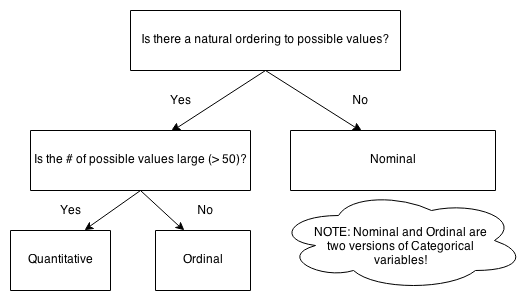

- What type of **variable** is in the K-Packs example?
- Let's get more practice with a worksheet

### Random Variables...

- What is a **random** variable? In other words, what makes a variable **random**? (Hint: the answer is quite simple)
  - If we have **not observed** the variable, then it is random!
  - A random variable represents our **belief** about **possible values**.
  - In general, capital letters denote a random variable and lower case letters denote an observed value.
  - For example, let x be the number of beers I consumed last night and X be the number of beers I consume this Friday.
  - With this framework, I can say: “What is the chance (or probability) that the # of beers I consume this Friday is larger than what I consumed last night?”

### Processes

- Fundamental to many business decisions. For example, monthly sales at company X is a process.
- Predicting future sales can be incredibly difficult. In stat 326, you'll learn how to forecast.

[figure not shown]

- The graphic below contains similar **time series** data on monthly sales. What's the difference?

[figure not shown]

- Is one graphic better than the other?
- Quality is a matter of context (and sometimes preference). There is an entire field focused on these problems!

### Data Visualization

There is more than one way to represent the same [data](http://www.nanocubes.net/view.html).

[interactive chart not shown]

[figure not shown]

- Take away: Don't mislead your audience!

### Less is more!

[figure not shown]

### What's a 226 student to do?

1. Identify the **variable** of interest.
2. Identify whether the variable is **categorical** or **quantitative**.
3. If variable is **categorical** (chapter 3), you're options are:
   - **Bar chart** (recommended)
   - **Pareto chart** (recommended)
   - **Pie chart** (not recommended)
4. If variable is **quantitative** (chapter 4), you're options are:
   - **Histogram** (good for examining a single **distribution**)
   - **Boxplot** (good for comparing multiple **distributions**)